# Linear Baseline for Dachshund Detection

1. Data processing
2. Dimensionality reduction
3. Logistic regression
4. SVMs

In this notebook we establish a baseline for our binary classification problem of distinguishing dachshunds from other dog breeds. For simplicity we only work with greyscale images and we further apply PCA to reduce the dimension of the input space for our models. We will then fit simple logistic regression and SVM models to the reduced data. These are then used as a baseline to evaluate the more advanced convolutional neural network models that we'll explore in the follow-up notebook. There would be multiple ways to improve the approach presented in this notebook, such as considering small patches of each image or using all 3 channels, but we won't delve into any of that for now.

```python
%matplotlib inline
import numpy as np
import PIL
import PIL.Image
import os
import matplotlib.pyplot as plt
from sklearn.model_selection import train_test_split, learning_curve
from sklearn.linear_model import LogisticRegression, LogisticRegressionCV

img_height, img_width = 224, 224
data_types = ['.jpg', '.jpeg', '.png']
```

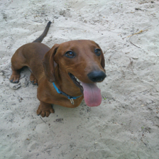

```python
def get_images(path):
    return [os.path.join(path, i) for i in os.listdir(path) if os.path.splitext(i)[1] in data_types]

dachshunds = get_images(os.path.join('data', 'dachshund'))
others = get_images(os.path.join('data', 'other'))
PIL.Image.open(dachshunds[5]).resize((img_height,img_width))
```

## 1. Data processing

We discuss the data, its collection, contents and noisiness more thoroughly in our CNN notebook. Here, we are content with just processing the data by converting the images to greyscale, scaling the pixel values to [0,1] and storing each picture as a row vector in the design matrix $X$. The labels in the vector $y$ are 1 for dachshund and -1 for other. Finally, we centre the data by subtracting the mean per image and then split the processed data into train and validation sets with a 80-20 split.

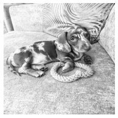

```python
def preprocess(img):
    return np.reshape((np.asarray(img.convert('L')) / 255.).astype(np.float32),(1,-1))

data = dict()
data['data'] = []
data['label'] = []

for dog in dachshunds:
    img = PIL.Image.open(dog).resize((img_width, img_height))
    data['data'].append(preprocess(img))
    data['label'].append(1)

for dog in others:
    img = PIL.Image.open(dog).resize((img_width, img_height))
    data['data'].append(preprocess(img))
    data['label'].append(-1)

plt.imshow(data['data'][13].reshape(224,224),cmap='gray')
plt.axis(False);
```

```python
X = np.concatenate(data['data'], axis=0)
y = np.array(data['label'])
X.shape, y.shape, y.sum() # as we see the classes are fairly balanced
```

```
((2126, 50176), (2126,), 12)
```

```python
X_norm = X - X.mean(axis=1,keepdims=True)
X_train, X_val, y_train, y_val = train_test_split(X_norm, y, test_size=0.2, stratify=y, shuffle=True, random_state=0)
```

## 2. Dimensionality reduction

Usually when applying PCA it is crucial to normalise each feature of your data to have zero mean and unit variance. Since we're working with natural images of the real world the same procedure does not make as much sense. This is because of the following heuristic: we assume that each region in our image is sampled from the same distribution and thus all pixels should have roughly the same standard deviation across all images. But PCA is invariant under scalar multiplication, so dividing out the common standard deviation would have no effect. Therefore, we will only subtract out the mean, but we again have to be a bit careful. Instead of subtracting the per pixel means across the dataset (which should be identically distributed by our assumption), we centre each image by subtracting the per image mean from each pixel. This means that we're merely changing the intensity (brightness) of the pictures without affecting the actual content, which is seemingly the more sensible approach.

After this, we're ready to fit PCA to the training set to reduce the number of input features. We let `sklearn` automatically choose the target dimension so that the explained variance of the remaining features is at least 70% (we keep it rather low compared to more standard choices of ~95-99%). This turns out to be 50 features, which is a huge reduction from the original 50 176 (for the greyscale). Incidentally, aiming for more than 70% explained variance doesn't seem to be too helpful for us. This is most likely due to the limited amount of training data, which doesn't allow us to take advantage of more complicated features and risks high variance for the finished model.

```python
from sklearn.decomposition import PCA

pca = PCA(n_components=0.7, random_state=0)
X_train_pca = pca.fit_transform(X_train)
X_val_pca = pca.transform(X_val)
print(f"Number of principal components: {X_train_pca.shape[1]}")
```

```
Number of principal components: 50
```

Below we visualise the "eigendogs" (in decreasing order according to the amount of variance explained by each vector) and a sample of the input data projected onto these eigenvectors.

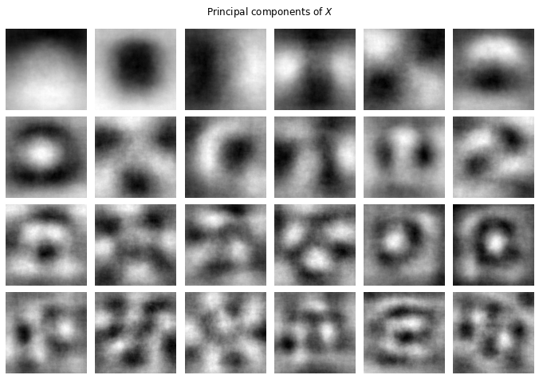

```python
fig, axs = plt.subplots(4,6,figsize=(9.5,6.7))
for i, ax in enumerate(axs.flat):
    ax.imshow(pca.components_[i].reshape((img_height, img_width)), cmap='gray')
    ax.axis(False)

fig.suptitle("Principal components of $X$")
fig.tight_layout()
plt.show()
```

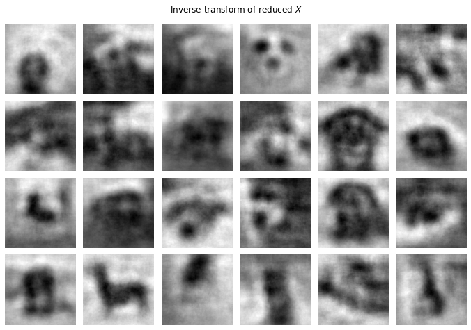

```python
fig, axs = plt.subplots(4,6,figsize=(9.5,6.7))
for i, ax in enumerate(axs.flat):
    ax.imshow(pca.inverse_transform(X_train_pca[i]).reshape((img_height, img_width)), cmap='gray')
    ax.axis(False)
fig.suptitle("Inverse transform of reduced $X$")
fig.tight_layout()
plt.show()
```

As we see there's a high reduction in the sharpness of the projected images and for some of them it's difficult even for humans to tell the classes apart. Therefore we conjecture that given this data and task, the irreducible error is rather high.

## 3. Logistic regression

Our first choice for a model is logistic regression. With this we obtain a modest ~59.8% accuracy, which is not completely awful considering the reasons outlined above. We emphasise again that in this notebook our aim is not to eke out every bit of performance from these models, but rather just to establish a quick reasonable baseline to which we can compare our neural network models. Therefore, we won't spend any time on optimising the hyperparameters.

```python
model_log = LogisticRegression(tol=0.001,
                               C=1,
                               solver='lbfgs',
                               penalty='l2',
                               max_iter=1000,
                               random_state=0
                              )
model_log.fit(X_train_pca, y_train)
print(f"Validation accuracy of logistic regression: {model_log.score(X_val_pca, y_val)}")
```

```
Validation accuracy of logistic regression: 0.5985915492957746
```

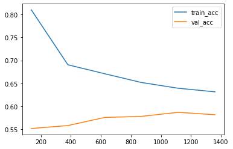

```python
train_sizes, train_scores, valid_scores = learning_curve(
    model_log, X_train_pca, y_train,
    train_sizes=np.linspace(0.1, 1., 6),
    cv=5,
    shuffle=True,
    scoring='accuracy'
)
plt.plot(train_sizes, np.mean(train_scores,axis=1), label='train_acc')
plt.plot(train_sizes, np.mean(valid_scores,axis=1), label='val_acc')
plt.legend();
```

It seems our model exhibits high bias (as expected) and mild/moderate variance. Due to the huge reduction in input dimensions after PCA, we've been able to avoid the extremely high variance that would otherwise be present.

## 4. SVMs

Compared to the logistic regression model, the SVM one has a slightly better performance due to a lower bias. However, we have to apply stronger regularisation to keep the variance under control. We end up with 61.2% accuracy.

```python
from sklearn.svm import SVC
from sklearn.model_selection import learning_curve

model_svm = SVC(random_state=0, C=0.3)
model_svm.fit(X_train_pca, y_train)
print(f"Validation accuracy of SVM: {model_svm.score(X_val_pca, y_val)}")
```

```
Validation accuracy of SVM: 0.6126760563380281
```

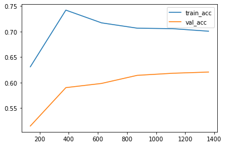

```python
train_sizes, train_scores, valid_scores = learning_curve(
    model_svm, X_train_pca, y_train,
    train_sizes=np.linspace(0.1, 1., 6),
    cv=5,
    shuffle=True,
    scoring='accuracy'
)
plt.plot(train_sizes, np.mean(train_scores,axis=1), label='train_acc')
plt.plot(train_sizes, np.mean(valid_scores,axis=1), label='val_acc')
plt.legend();
```